# DVT Data Analysis (Final)

Anaqi Amir

2024-01-22

# Introduction

This project was then in collaboration with Dr. Federico Carini (University of Toronto) and Professor Sotirious Damouras (University of Toronto, Scarborough).

# Setup

## Imports

```r
library(readxl)
library(tidyverse)
library(epitools)
library(naniar)
```

## Load Data

```r
# Reading the excel file
df = read_excel('/Users/Anaqi_Amir/Downloads/DVTRetrospective22_DataCollection_CariniCurrent_DVTHemOncDEIDENTIFIED.xlsx', sheet = 'DataCollection')

# Head of df
df
```

| study_id | first_icu_ad | Male | age | hem_malig | year_diagnosis | dxtime | dx1y | mv | o2 | dialysis | pressors | hospital_admission_date | icu_admission_date | icu_discharge_date | icu_disposition | hospital_discharge_date | hospital_disposition | dnr_icu | dnr_ward | pre_icu_los | icu_los | hospital_los | hospital_ad_dx | icu_diag | weight | height | bmi | covid | cmbd_htn | … |
| --- | --- | --- | --- | --- | --- | --- | --- | --- | --- | --- | --- | --- | --- | --- | --- | --- | --- | --- | --- | --- | --- | --- | --- | --- | --- | --- | --- | --- | --- | --- |
| 1 | 1 | 0 | 76.63562 | 2 | 2014 | 0 | 0 | 1 | 0 | 0 | 1 | 2014-03-18 | 2014-03-19 | 2014-03-20 | 1 | 41718 | 1 | 1 | 0 | 1 | 1 | 2 | 4 | 2 | 75 | 1.61 | 28.934068901662741 | 0 | 1 | … |
| 2 | 1 | 1 | 33.01644 | 2 | 2012 | 2 | 1 | 1 | 0 | 0 | 0 | 2014-01-17 | 2014-01-19 | 2014-01-20 | 2 | 41668 | 1 | 0 | 1 | 2 | 1 | 12 | 8 | 2 | 65 | 1.66 | 23.588329220496444 | 0 | 0 | … |
| 3 | 1 | 1 | 67.11233 | 2 | 2007 | 9 | 1 | 2 | 2 | 0 | 0 | 2016-11-23 | 2016-11-23 | 2016-11-25 | 2 | 42750 | 1 | 0 | 0 | 0 | 2 | 53 | 1 | 8 | 80 | 1.79 | 24.968009737523797 | 0 | 0 | … |
| 4 | 1 | 0 | 69.12877 | 7 | 2018 | 0 | 0 | 1 | 0 | 0 | 0 | 2018-12-24 | 2019-01-12 | 2019-02-06 | 2 | 43537 | 2 | 0 | 0 | 19 | 25 | 79 | 4 | 2 | 55 | 1.52 | 23.80540166204986 | 0 | 1 | … |
| 5 | 1 | 1 | 79.05753 | 2 | 2020 | 0 | 0 | 1 | 0 | 0 | 1 | 2020-09-24 | 2020-09-24 | 2020-09-25 | 1 | 44099 | 1 | 0 | 0 | 0 | 1 | 1 | 4 | 6 | 70 | 1.55 | 29.136316337148799 | 0 | 0 | … |
| 6 | 1 | 1 | 59.25205 | 9 | 2017 | 0 | 0 | 1 | 0 | 1 | 1 | 2017-10-26 | 2018-01-11 | 2018-01-14 | 1 | 43114 | 1 | 0 | 0 | 77 | 3 | 80 | 4 | 2 | 95 | 1.76 | 30.668904958677686 | 0 | 0 | … |
| 7 | 1 | 0 | 72.41370 | 6 | 2015 | 0 | 0 | 1 | 1 | 1 | 1 | 2015-09-27 | 2015-09-27 | 2015-09-30 | 1 | 42277 | 1 | 1 | 0 | 0 | 3 | 3 | 1 | 1 | 93 | 1.52 | 40.25277008310249 | 0 | 1 | … |
| 8 | 1 | 1 | 64.02466 | 2 | 2018 | 1 | 1 | 0 | 2 | 0 | 0 | 2019-05-02 | 2019-05-07 | 2019-05-07 | 2 | 43635 | 2 | 0 | 0 | 5 | 0 | 48 | 4 | 7 | 62 | 1.68 | 21.9671201814059 | 0 | 0 | … |
| 9 | 1 | 0 | 75.55616 | 2 | 2021 | 0 | 0 | 0 | 3 | 0 | 1 | 2021-10-19 | 2021-12-06 | 2021-12-08 | 2 | 44548 | 2 | 0 | 0 | 48 | 2 | 60 | 4 | 7 | 64 | 1.58 | 25.63691716071142 | 0 | 1 | … |
| 10 | 1 | 0 | 67.42466 | 2 | 2015 | 0 | 0 | 0 | 0 | 0 | 1 | 2015-02-10 | 2015-02-10 | 2015-02-11 | 2 | 42059 | 2 | 0 | 0 | 0 | 1 | 14 | 1 | 1 | 52 | 1.66 | 18.870663376397157 | 0 | 0 | … |

[output cut: 852 more lines]

# Basic data exploration

## Overview

```r
# Shape of data
dim(df)
```

```
## [1] 862  94
```

```r
# Summary of data
summary(df)
```

```
##     study_id      first_icu_ad         Male             age
##  Min.   :  1.0   Min.   :0.0000   Min.   :0.0000   Min.   :19.08
##  1st Qu.:216.2   1st Qu.:1.0000   1st Qu.:0.0000   1st Qu.:50.24
##  Median :431.5   Median :1.0000   Median :1.0000   Median :61.49
##  Mean   :431.8   Mean   :0.9466   Mean   :0.5882   Mean   :57.86
##  3rd Qu.:645.8   3rd Qu.:1.0000   3rd Qu.:1.0000   3rd Qu.:68.76
##  Max.   :864.0   Max.   :1.0000   Max.   :1.0000   Max.   :94.13
##    hem_malig     year_diagnosis        dxtime              dx1y
##  Min.   :1.000   Length:862         Length:862         Length:862
##  1st Qu.:2.000   Class :character   Class :character   Class :character
##  Median :2.000   Mode  :character   Mode  :character   Mode  :character
##  Mean   :3.423
##  3rd Qu.:6.000
##  Max.   :9.000
##        mv              o2              dialysis           pressors
##  Min.   :0.0000   Length:862         Length:862         Length:862
##  1st Qu.:0.0000   Class :character   Class :character   Class :character
##  Median :1.0000   Mode  :character   Mode  :character   Mode  :character
##  Mean   :0.6183
##  3rd Qu.:1.0000
##  Max.   :2.0000
##  hospital_admission_date          icu_admission_date
##  Min.   :2013-12-10 00:00:00.00   Min.   :2014-01-02 00:00:00.00
##  1st Qu.:2015-11-15 06:00:00.00   1st Qu.:2015-11-18 00:00:00.00
##  Median :2017-12-14 00:00:00.00   Median :2018-01-04 12:00:00.00
##  Mean   :2017-12-09 06:37:35.22   Mean   :2017-12-23 04:05:34.10
##  3rd Qu.:2020-01-06 06:00:00.00   3rd Qu.:2020-01-19 12:00:00.00
##  Max.   :2022-01-24 00:00:00.00   Max.   :2022-01-26 00:00:00.00
##  icu_discharge_date               icu_disposition hospital_discharge_date
##  Min.   :2014-01-08 00:00:00.00   Min.   :1.000   Length:862
##  1st Qu.:2015-11-23 06:00:00.00   1st Qu.:1.000   Class :character
##  Median :2018-01-13 00:00:00.00   Median :2.000   Mode  :character
##  Mean   :2017-12-29 00:03:20.46   Mean   :1.697
##  3rd Qu.:2020-01-22 18:00:00.00   3rd Qu.:2.000
##  Max.   :2022-01-28 00:00:00.00   Max.   :4.000
##  hospital_disposition    dnr_icu        dnr_ward          pre_icu_los
##  Length:862           Min.   :0.000   Length:862         Min.   :  0.00
##  Class :character     1st Qu.:0.000   Class :character   1st Qu.:  1.00
##  Mode  :character     Median :0.000   Mode  :character   Median :  7.00
##                       Mean   :0.326                      Mean   : 13.89
```

[output cut: 120 more lines]

```
##                     Max.   :1.0000                      Max.   :1.0000
##   plasma_qty           Others           others_qty         VTE_compl
##  Length:862         Length:862         Length:862         Length:862
##  Class :character   Class :character   Class :character   Class :character
##  Mode  :character   Mode  :character   Mode  :character   Mode  :character
##
##
##
##     Notes
##  Length:862
##  Class :character
##  Mode  :character
##
##
##
```

## Missing values

The presence of missing values significantly influences the integrity of data analysis, potentially resulting in distorted findings. Accordingly, it is imperative to meticulously examine and address any missing values in the dataset prior to initiating the analysis, ensuring a proactive approach to managing such instances during the subsequent analytical procedures.

I will be using the `vis_miss` function from the `naniar` package to visualize missing data. Note that each dark line represent a missing value in its corresponding column.

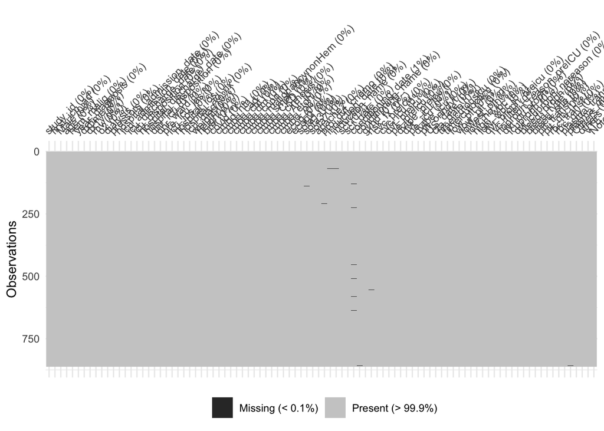

```r
vis_miss(df)
```

As we can see, there are minimal missing values in the dataset. Even though this is the case, I have decided to not remove these rows that contain missing values as the incidence rates of the factors that we would be observing are extremely low; therefore, removing rows might greatly affect the interpretation and analysis of our results in the future.

A modification that can be made to my report would be to fill in these missing values through the most appropriate technique (fill with mean, fill with a regression model, etc.), but I would not do that in this report.

# Data Analysis

This section is divided into 3 sub-sections as requested by Dr. Carini. The purposes of each sub-section is simply to investigate the relationshop between various factors and how they affect one another. All analysis in this report are strictly bivariate, i.e., this report only looks at the relationship between two factors at a time.

## Section 1: Prophylaxis

In this section, I looked at the relationship between various factors in a patient’s health, and the presence of prophlyaxis in those patients. Here are the results:

```r
prophylaxis_table = read.table("Prophylaxis analysis")
knitr::kable(prophylaxis_table, "simple")
```

|  | n | Incidence.Rate | Odds.Ratio..95..CI. | p.value |
| --- | --- | --- | --- | --- |
| Biologically Male vs SCDs | 507 | 0.44 | 1.20 (0.91 - 1.58) | 0.20 |
| Biologically Male vs Pharmacological | 507 | 0.19 | 0.67 (0.48 - 0.92) | 0.01* |
| Biologically Male vs No Proph | 507 | 0.20 | 0.94 (0.67 - 1.31) | 0.70 |
| Biologically Female vs SCDs | 355 | 0.40 | 0.84 (0.63 - 1.10) | 0.20 |
| Biologically Female vs Pharmacological | 355 | 0.26 | 1.50 (1.09 - 2.08) | 0.01* |
| Biologically Female vs No Proph | 355 | 0.21 | 1.09 (0.76 - 1.49) | 0.70 |
| Plt<=20 vs SCDs | 496 | 0.54 | 3.23 (2.42 - 4.34) | 4.44e-16* |
| Plt<=20 vs Pharmacological | 496 | 0.09 | 0.15 (0.10 - 0.21) | 2.13e-27 (Chi Square)* |
| Plt<=20 vs No Proph | 496 | 0.23 | 1.30 (0.93 - 1.83) | 0.13 |
| 20<Plt<50 vs SCDs | 199 | 0.37 | 0.73 (0.52 - 1.01) | 0.06 |
| 20<Plt<50 vs Pharamcological | 199 | 0.26 | 1.32 (0.91 - 1.90) | 0.14 |
| 20<Plt<50 vs No Proph | 199 | 0.22 | 1.07 (0.72 - 1.57) | 0.73 |
| Low HB vs SCDs | 457 | 0.49 | 1.71 (1.30 - 2.25) | 1.25e-4 (Chi Square)* |
| Low HB vs Pharmacological | 457 | 0.14 | 0.33 (0.24 - 0.47) | 6.74e-11* |
| Low HB vs No Proph | 457 | 0.22 | 1.22 (0.87 - 1.70) | 0.25 |
| High WBC vs SCDs | 132 | 0.41 | 0.92 (0.63 - 1.34) | 0.67 |
| High WBC vs Pharmacological | 132 | 0.23 | 1.08 (0.69 - 1.66) | 0.73 |
| High WBC vs No Proph | 132 | 0.15 | 0.65 (0.38 - 1.05) | 0.08 |
| Low WBC vs SCDs | 451 | 0.50 | 1.88 (1.43 - 2.48) | 5.33e-6* |
| Low WBC vs Pharmacological | 451 | 0.13 | 0.31 (0.22 - 0.43) | 2.69e-12* |
| Low WBC vs No Proph | 451 | 0.22 | 1.20 (0.86 - 1.67) | 0.29 |
| Pre-ICU proph vs SCDs | 83 | 0.24 | 0.40 (0.23 - 0.66) | 2.58e-4* |
| Pre-ICU proph vs Pharmacological | 83 | 0.55 | 5.37 (3.36 - 8.64) | 4.02e-12* |
| Pre-ICU proph vs No proph | 83 | 0.14 | 0.63 (0.32 - 1.14) | 0.13 |
| > 61 years old vs SCDs | 442 | 0.42 | 0.96 (0.73 - 1.26) | 0.76 |
| > 61 years old vs Pharmacological | 442 | 0.24 | 1.22 (0.89 - 1.69) | 0.22 |
| > 61 years old vs No Proph | 442 | 0.18 | 0.74 (0.53 - 1.03) | 0.07 |

## Section 2: Catheters

In this section, I looked at the relationship between various factors in a patient’s health, and the presence of catheters in those patients. Here are the results:

```r
catheter_table = read.table("Catheter analysis")
knitr::kable(catheter_table, "simple")
```

|  | n | Incidence.Rate | Odds.Ratio..95..CI. | p.value |
| --- | --- | --- | --- | --- |
| SCDs vs DVT | 367 | 0.04 | 0.88 (0.42 - 1.78) | 0.72 |
| SCDs vs PE | 367 | 0.01 | 0.34 (0.07 - 1.11) | 0.08 |
| Pharma Proph vs DVT | 192 | 0.06 | 2.07 (0.96 - 4.23) | 0.06 |
| Pharma Proph vs PE | 192 | 0.03 | 2.39 (0.77 - 6.81) | 0.12 |
| No prophylaxis vs DVT | 179 | 0.02 | 0.53 (0.15 - 1.38) | 0.21 |
| No prophylaxis vs PE | 179 | 0.03 | 2.62 (0.85 - 7.47) | 0.09 |
| Plt>=50 vs DVT | 167 | 0.05 | 1.36 (0.56 - 2.97) | 0.47 |
| Plt>=50 vs PE | 167 | 0.02 | 1.08 (0.23 - 3.50) | 0.91 |
| 20<Plt<50 vs DVT | 199 | 0.04 | 1.08 (0.45 - 2.35) | 0.85 |
| 20<Plt<50 vs PE | 199 | 0.03 | 1.71 (0.51 - 4.94) | 0.36 |
| Plt<=20 vs DVT | 496 | 0.03 | 0.78 (0.38 - 1.58) | 0.48 |
| Plt<=20 vs PE | 496 | 0.01 | 0.64 (0.22 - 1.84) | 0.40 |

## Section 3: Others

In this section, I looked at a few others relationships between factors that I think would be of value.

```r
others_table = read.table("Other findings")
knitr::kable(others_table, "simple")
```

|  | n | Incidence.Rate | Odds.Ratio..95..CI. | p.value |
| --- | --- | --- | --- | --- |
| Major bleeding vs Death | 122 | 0.41 | 1.40 (0.94 - 2.07) | 0.09 |
| SCDs vs Death | 367 | 0.35 | 1.05 (0.79 - 1.40) | 0.73 |
| DVT vs Death | 33 | 0.18 | 0.42 (0.15 - 0.98) | 0.04* |
| PE vs Death | 15 | 0.40 | 1.30 (0.42 - 3.69) | 0.63 |
| DVT vs Major bleeding | 33 | 0.15 | 1.11 (0.37 - 2.73) | 0.83 |

# Hypothesis

In this section, I will be investigating the hypothesis proposed by Dr. Carini through 3 consecutive steps as follows:

$\textbf{Hypothesis}$: In critically ill patients with hematologic malignancy (HM) who are thrombocytopenic, venous thromboembolism (VTE) is infrequent within the first 30 days following induction chemotherapy or hematopoietic cell transplant (HCT), rendering it possible to avoid the use of thromboprophylaxis (mechanical or pharmacological) and the associated risks (i.e. serious bleeding).

$\underline{Step \hspace{1mm} 1}$: Find the correlation between thromboprophylaxis and bleeding. This is to show that thromboprophylaxis does indeed lead to the patients developing bleeding symptoms.

$\underline{Step \hspace{1mm} 2}$: Filter the data to find the target demographic of critically ill patients with HM who are thrombocytopenic that either underwent chemo or HCT.

$\underline{Step \hspace{1mm} 3}$: Find the incidence rate of VTE of the patients from the filtered data within the first 30 days of the induction of either chemo or HCT.

## Step 1

I will calculate the odd ratios of the following combinations:  
- Mechanical prophylaxis (SCDs, Compression Stockings) vs Major Bleeding  
- Mechanical prophylaxis (SCDs, Compression Stockings) vs Minor Bleeding  
- Pharmological prophylaxis (LMWH, Unfractioned heparin, Oral anticoagulants) vs Major Bleeding  
- Pharmological prophylaxis (LMWH, Unfractioned heparin, Oral anticoagulants) vs Minor Bleeding

```r
step1_table = read.table("Step 1")
knitr::kable(step1_table, "simple")
```

|  | n | Incidence.Rate | Odds.Ratio..95..CI. | p.value |
| --- | --- | --- | --- | --- |
| Mechanical vs Major Bleeding | 367 | 0.16 | 1.21 (0.83 - 1.79) | 0.32 |
| Pharma Proph vs Major bleeding | 196 | 0.05 | 0.27 (0.13 - 0.50) | 7.73e-06* |
| Mechanical vs Minor Bleeding | 62 | 0.52 | 1.48 (0.88 - 2.50) | 0.14 |
| Pharma Proph vs Minor bleeding | 39 | 0.23 | 0.42 (0.19 - 0.87) | 0.02* |

## Step 2

Filter data to find the intended demographic. We mange to reduce the rows from 862 to only 695.

## Step 3

Finding the incidence rates. Here are the results:

```r
step3_table = read.table("Step 3")
knitr::kable(step3_table, "simple")
```

|  | n | Incidence.Rate | Odds.Ratio..95..CI. | p.value |
| --- | --- | --- | --- | --- |
| SCDs vs VTE within 30 days | 171 | 0.92 | 0.57 (0.17 - 1.58) | 0.29 |
| Pharma Proph vs VTE within 30 days | 65 | 0.98 | 4.37 (0.88 - 105.99) | 0.08 |

# Conclusion